# Class 9

Tobias Gerstenberg

February 1st, 2021

# 9 Modeling data

## 9.1 Load packages and set plotting theme

```r
library("knitr")      # for knitting RMarkdown
library("kableExtra") # for making nice tables
library("janitor")    # for cleaning column names
library("tidyverse")  # for wrangling, plotting, etc.
```

```r
theme_set(theme_classic() + #set the theme
            theme(text = element_text(size = 20))) #set the default text size

opts_chunk$set(comment = "",
               fig.show = "hold")
```

## 9.2 Modeling data

### 9.2.1 Simplicity vs. accuracy trade-off

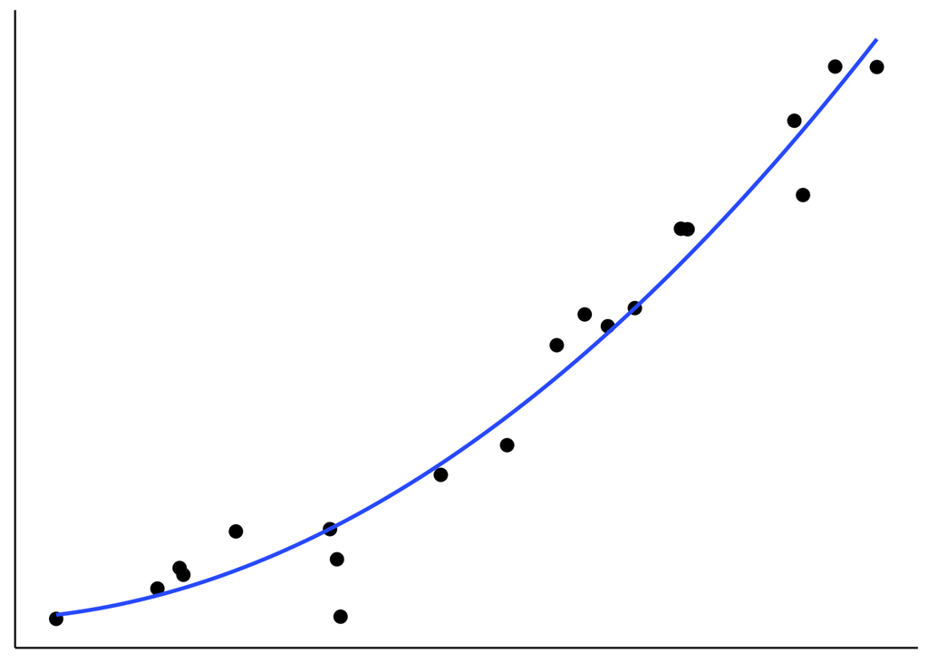

Figure 9.1: Tradeoff between fit and model simplicity.

```r
# make example reproducible
set.seed(1)

n_samples = 20 # sample size
n_parameters = 2 # number of parameters in the polynomial regression

# generate data
df.data = tibble(x = runif(n_samples, min = 0, max = 10),
                 y = 10 + 3 * x + 3 * x^2 + rnorm(n_samples, sd = 20))

# plot a fit to the data
ggplot(data = df.data,
       mapping = aes(x = x,
                     y = y)) +
  geom_point(size = 3) +
  # geom_hline(yintercept = mean(df.data$y), color = "blue") +
  geom_smooth(method = "lm", se = F,
              formula = y ~ poly(x, degree = n_parameters, raw = TRUE)) +
  theme(axis.ticks = element_blank(),
        axis.title = element_blank(),
        axis.text = element_blank())
```

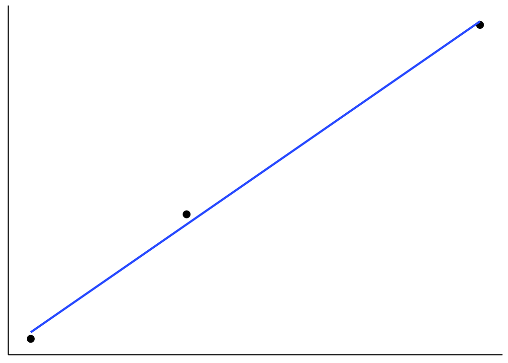

Figure 9.2: Figure that I used to illustrate that fitting more data points with fewer parameter is more impressive.

```r
# make example reproducible
set.seed(1)
# n_samples = 20
n_samples = 3

df.pre = tibble(x = runif(n_samples, min = 0, max = 10),
                y = 2 * x + rnorm(n_samples, sd = 1))

# plot a fit to the data
ggplot(data = df.pre,
       mapping = aes(x = x,
                     y = y)) +
  geom_point(size = 3) +
  # geom_hline(yintercept = mean(df.pre$y), color = "blue") +
  geom_smooth(method = "lm", se = F,
              formula = y ~ poly(x, 1, raw = TRUE)) +
  theme(axis.ticks = element_blank(),
        axis.title = element_blank(),
        axis.text = element_blank())
```

### 9.2.2 Error definitions and best estimators

Let’s start with some simple data:

```r
df.data = tibble(observation = 1:5,
                 value = c(1, 3, 5, 9, 14))
```

And plot the data

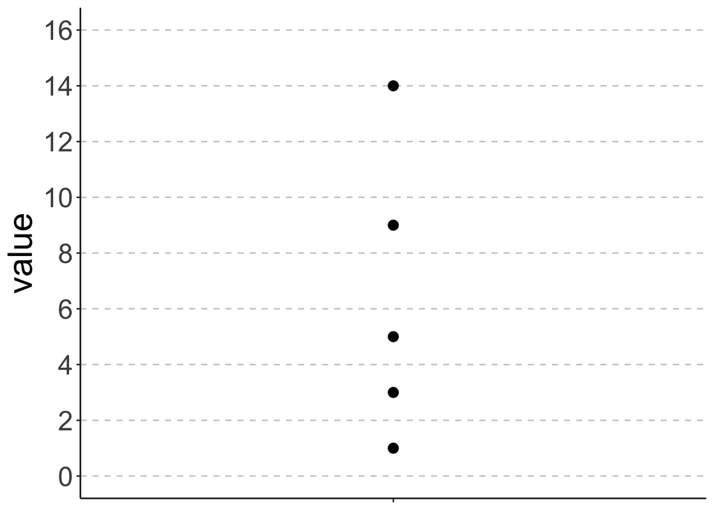

```r
ggplot(data = df.data,
       mapping = aes(x = "1",
                     y = value)) +
  geom_point(size = 3) +
  scale_y_continuous(breaks = seq(0, 16, 2),
                     limits = c(0, 16)) +
  theme(panel.grid.major.y = element_line(color = "gray80", linetype = 2),
        axis.title.x = element_blank(),
        axis.text.x = element_blank(),
        text = element_text(size = 24))
```

This is what the sum of absolute errors looks like for a given `value_predicted`.

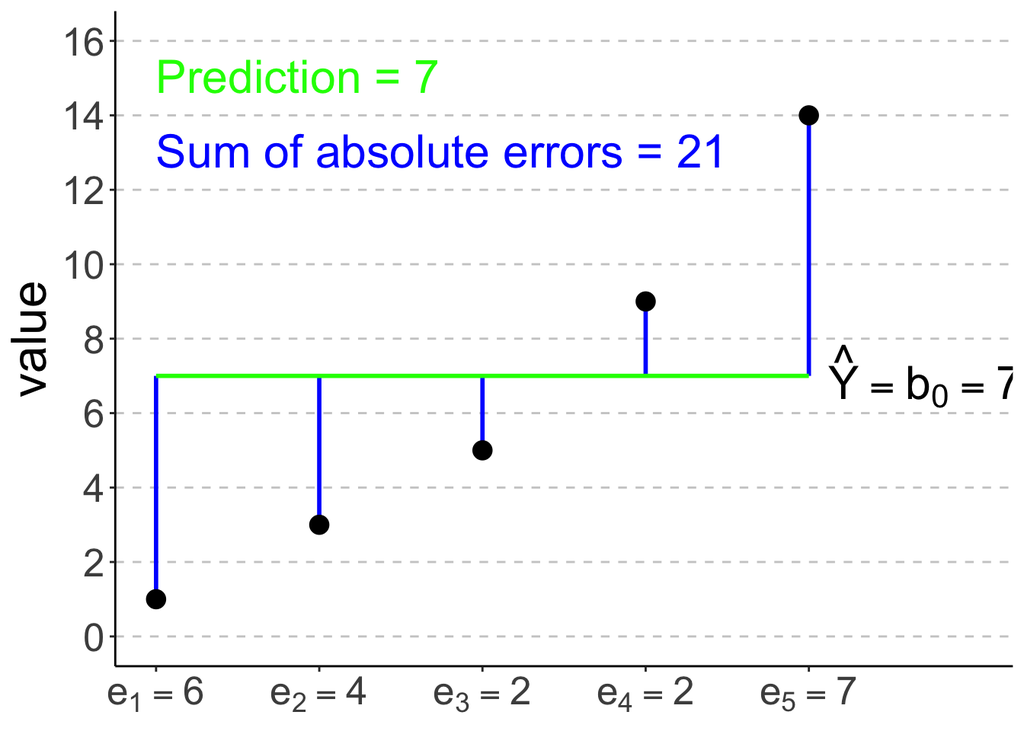

Figure 9.3: Sum of absolute errors.

```r
value_predicted = 7

df.data = df.data %>%
  mutate(prediction = value_predicted,
         error_absolute = abs(prediction - value))

ggplot(data = df.data,
       mapping = aes(x = observation,
                     y = value)) +
  geom_segment(mapping = aes(x = observation,
                             xend = observation,
                             y = value_predicted,
                             yend = value
                             ),
               color = "blue",
               size = 1) +
  geom_line(data = tibble(x = c(1, 5),
                   y = value_predicted),
            mapping = aes(x = x,
                y = y),
            size = 1,
            color = "green") +
  geom_point(size = 4) +
  annotate(x = 1,
           y = 15.5,
           geom = "text",
           label = str_c("Prediction = ", value_predicted),
           size = 8,
           hjust = 0,
           vjust = 1,
           color = "green") +
  annotate(x = 1,
           y = 13.5,
           geom = "text",
           label = str_c("Sum of absolute errors = ", sum(df.data$error_absolute)),
           size = 8,
           hjust = 0,
           vjust = 1,
           color = "blue") +
  annotate(x = 5,
           y = value_predicted,
           geom = "text",
           label = parse(text = str_c("{hat(Y)","==b[0]}==", value_predicted)),
           hjust = -0.1,
           size = 8) +
  scale_x_continuous(breaks = df.data$observation,
                     labels = parse(text = str_c('e[',df.data$observation,']', "==", df.data$error_absolute)),
                     limits = c(1, 6)) +
  scale_y_continuous(breaks = seq(0, 16, 2),
                     limits = c(0, 16)) +
  theme(panel.grid.major.y = element_line(color = "gray80", linetype = 2),
        axis.title.x = element_blank(),
        text = element_text(size = 24))
```

Play around with the code below to see how using (1) the sum of absolute errors, or (2) the sum of squared errors affects what estimate minimizes the error.

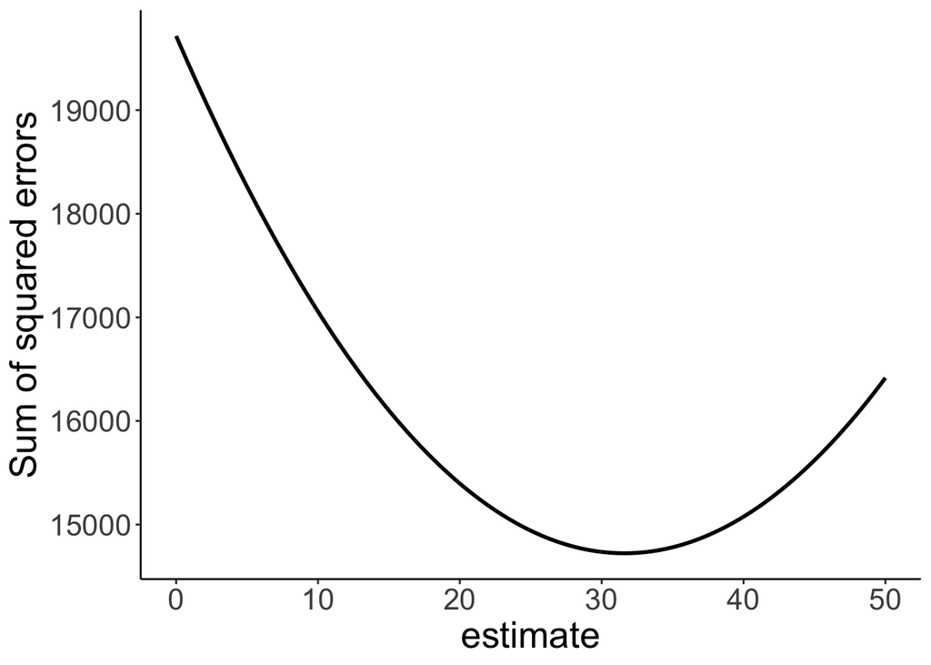

| Error definition | Best estimator |
| --- | --- |
| Count of errors | Mode = most frequent value |
| Sum of absolute errors | Median = middle observation of all values |
| Sum of squared errors | Mean = average of all values |

```r
value_predicted = seq(0, 50, 0.1)
# value_predicted = seq(0, 10, 1)

df.data = tibble(observation = 1:5,
                 value = c(1, 3, 5, 9, 140))

# function that calculates the sum absolute error
fun.sum_absolute_error = function(prediction){
  x = df.data$value
  sum_absolute_error = sum(abs(x-prediction))
  return(sum_absolute_error)
}

# function that calculates the sum squared error
fun.sum_squared_error = function(prediction){
  x = df.data$value
  sum_squared_error = sum((x-prediction)^2)
  return(sum_squared_error)
}

df.model = tibble(
  estimate = value_predicted,
  sum_absolute_error = map_dbl(value_predicted, fun.sum_absolute_error),
  sum_squared_error = map_dbl(value_predicted, fun.sum_squared_error)
)

ggplot(data = df.model,
       mapping = aes(x = estimate,
                     # y = sum_absolute_error)) +
                     y = sum_squared_error)) +
  geom_line(size = 1) +
  # labs(y = "Sum absolute error")
  labs(y = "Sum of squared errors")
```

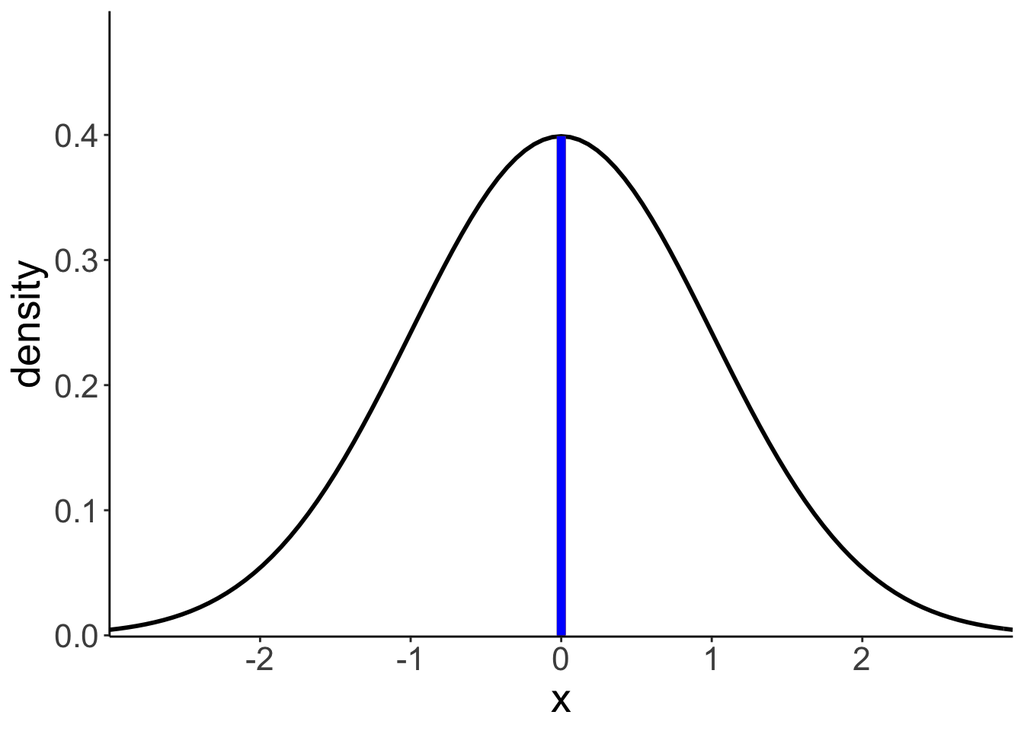

Figure 9.4: Mean, median, and mode on the normal distribution.

```r
mu = 0
sigma = 1

mean = mu
median = mu
mode = mu

ggplot(data = tibble(x = c(-3, 3)),
       mapping = aes(x = x)) +
  stat_function(fun = "dnorm",
                size = 1) +
  geom_segment(mapping = aes(x = median,
                             xend = median,
                             y = dnorm(median),
                             yend = 0),
               color = "green",
               size = 2) +
  geom_segment(mapping = aes(x = mode,
                             xend = mode,
                             y = dnorm(mode),
                             yend = 0),
               color = "red",
               size = 2) +
  geom_segment(mapping = aes(x = mean,
                             xend = mean,
                             y = dnorm(mean),
                             yend = 0),
               color = "blue",
               size = 2) +
  labs(y = "density") +
  scale_x_continuous(breaks = -2:2,
                     expand = c(0, 0)) +
  scale_y_continuous(expand = expansion(add = c(0.001, 0.1)))
```

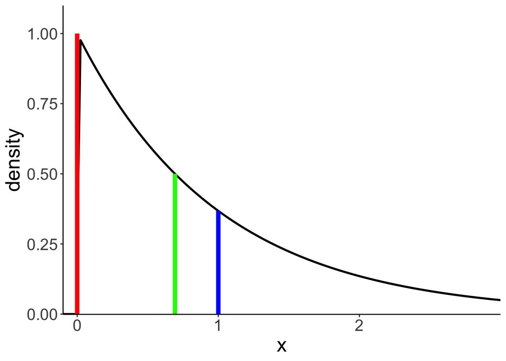

Figure 9.5: Mean, median, and mode on the exponential distribution.

```r
rate = 1

mean = rate
median = rate * log(2)
mode = 0

ggplot(data = tibble(x = c(-0.1, 3)),
            mapping = aes(x = x)) +
  stat_function(fun = "dexp",
                size = 1) +
  geom_segment(aes(x = median,
                   xend = median,
                   y = dexp(median),
                   yend = 0),
               color = "green",
               size = 2) +
  geom_segment(aes(x = mode,
                   xend = mode,
                   y = dexp(mode),
                   yend = 0),
               color = "red",
               size = 2) +
  geom_segment(aes(x = mean,
                   xend = mean,
                   y = dexp(mean),
                   yend = 0),
               color = "blue",
               size = 2) +
  labs(y = "density") +
  scale_x_continuous(breaks = 0:2,
                     expand = c(0, 0)) +
  scale_y_continuous(expand = expansion(add = c(0.001, 0.1)))
```

### 9.2.3 Sampling distributions for median and mean

```r
# make example reproducible
set.seed(1)

sample_size = 40 # size of each sample
sample_n = 1000 # number of samples

# draw sample
fun.draw_sample = function(sample_size, distribution){
  x = 50 + rnorm(sample_size)
  return(x)
}

# generate many samples
samples = replicate(n = sample_n,
                    fun.draw_sample(sample_size, df.population))

# set up a data frame with samples
df.sampling_distribution = matrix(samples, ncol = sample_n) %>%
  as_tibble(.name_repair = ~ str_c(1:sample_n)) %>%
  pivot_longer(cols = everything(),
               names_to = "sample",
               values_to = "number") %>%
  mutate(sample = as.numeric(sample)) %>%
  group_by(sample) %>%
  mutate(draw = 1:n()) %>%
  select(sample, draw, number) %>%
  ungroup()

# turn the data frame into long format and calculate the mean and median of each sample
df.sampling_distribution_summaries = df.sampling_distribution %>%
  group_by(sample) %>%
  summarize(mean = mean(number),
            median = median(number)) %>%
  ungroup() %>%
  pivot_longer(cols = -sample,
               names_to = "index",
               values_to = "value")
```

And plot it:

[figure not shown]

```r
# plot a histogram of the means with density overlaid

ggplot(data = df.sampling_distribution_summaries,
       mapping = aes(x = value, color = index)) +
  stat_density(bw = 0.1,
               size = 2,
               geom = "line") +
  scale_y_continuous(expand = expansion(mult = c(0, 0.01)))
```

## 9.3 Hypothesis testing: “One-sample t-test”

```r
df.internet = read_table2(file = "data/internet_access.txt") %>%
  clean_names()
df.internet %>%
  mutate(i = 1:n()) %>%
  select(i, internet, everything()) %>%
  head(10) %>%
  kable(digits = 1) %>%
  kable_styling(bootstrap_options = "striped",
              full_width = F)
```

| i | internet | state | college | auto | density |
| --- | --- | --- | --- | --- | --- |
| 1 | 79.0 | AK | 28.0 | 1.2 | 1.2 |
| 2 | 63.5 | AL | 23.5 | 1.3 | 94.4 |
| 3 | 60.9 | AR | 20.6 | 1.7 | 56.0 |
| 4 | 73.9 | AZ | 27.4 | 1.3 | 56.3 |
| 5 | 77.9 | CA | 31.0 | 0.8 | 239.1 |
| 6 | 79.4 | CO | 37.8 | 1.0 | 48.5 |
| 7 | 77.5 | CT | 37.2 | 1.0 | 738.1 |
| 8 | 74.5 | DE | 29.8 | 1.1 | 460.8 |
| 9 | 74.3 | FL | 27.2 | 1.2 | 350.6 |
| 10 | 72.2 | GA | 28.3 | 1.1 | 168.4 |

```r
# parameters per model
pa = 1
pc = 0

df.model = df.internet %>%
  select(internet, state) %>%
  mutate(i = 1:n(),
         compact_b = 75,
         augmented_b = mean(internet),
         compact_se = (internet-compact_b)^2,
         augmented_se = (internet-augmented_b)^2) %>%
  select(i, state, internet, contains("compact"), contains("augmented"))

df.model %>%
  summarize(augmented_sse = sum(augmented_se),
            compact_sse = sum(compact_se),
            pre = 1 - augmented_sse/compact_sse,
            f = (pre/(pa-pc))/((1-pre)/(nrow(df.model)-pa)),
            p_value = 1-pf(f, pa-pc, nrow(df.model)-1),
            mean = mean(internet),
            sd = sd(internet)) %>%
              kable() %>%
              kable_styling(bootstrap_options = "striped",
                          full_width = F)
```

| augmented_sse | compact_sse | pre | f | p_value | mean | sd |
| --- | --- | --- | --- | --- | --- | --- |
| 1355.028 | 1595.71 | 0.1508305 | 8.703441 | 0.0048592 | 72.806 | 5.258673 |

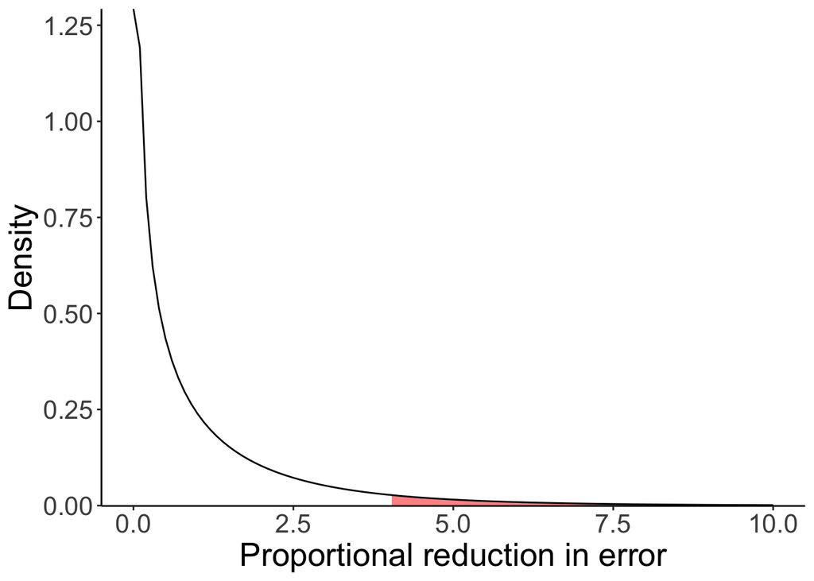

Figure 9.6: F-distribution

```r
df1 = 1
df2 = 49

ggplot(data = tibble(x = c(0, 10)),
       mapping = aes(x = x)) +
  stat_function(fun = "df",
                geom = "area",
                fill = "red",
                alpha = 0.5,
                args = list(df1 = df1,
                            df2 = df2),
                size = 1,
                xlim = c(qf(0.95, df1 = df1, df2 = df2), 10)) +
  stat_function(fun = ~ df(x = .,
                           df1 = df1,
                           df2 = df2),
                size = 0.5) +
  scale_y_continuous(expand = expansion(add = c(0.001, 0.1))) +
  labs(y = "Density",
       x = "Proportional reduction in error")
```

We’ve implemented a one sample t-test (compare the p-value here to the one I computed above using PRE and the F statistic).

```r
t.test(df.internet$internet, mu = 75)
```

```
    One Sample t-test

data:  df.internet$internet
t = -2.9502, df = 49, p-value = 0.004859
alternative hypothesis: true mean is not equal to 75
95 percent confidence interval:
 71.3115 74.3005
sample estimates:
mean of x
   72.806
```

## 9.4 Building a sampling distribution of PRE

Here is the general procedure for building a sampling distribution of the proportional reduction in error (PRE). In this instance, I compare the following two models

- Model C (compact): $Y_i = 75 + \epsilon_i$
- Model A (augmented): $Y_i = \overline Y + \epsilon_i$

whereby I assume that $\epsilon_i \sim \mathcal{N}(0, \sigma)$.

For this example, I assume that I know the population distribution. I first draw a sample from that distribution, and then calculate PRE.

```r
# make example reproducible
set.seed(1)

# set the sample size
sample_size = 50

# draw sample from the population distribution (I've fixed sigma -- the standard deviation
# of the population distribution to be 5)
df.sample = tibble(observation = 1:sample_size,
                   value = 75 + rnorm(sample_size, mean = 0, sd = 5))

# calculate SSE for each model, and then PRE based on that
df.summary = df.sample %>%
  mutate(compact = 75,
         augmented = mean(value)) %>%
  summarize(sse_compact = sum((value - compact)^2),
            sse_augmented = sum((value - augmented)^2),
            pre = 1 - (sse_augmented/sse_compact))
```

To generate the sampling distribution, I assume that the null hypothesis is true, and then take a look at what values for PRE we could expect by chance for our given sample size.

```
# A tibble: 1 x 1
  p_value
    <dbl>
1   0.394
```

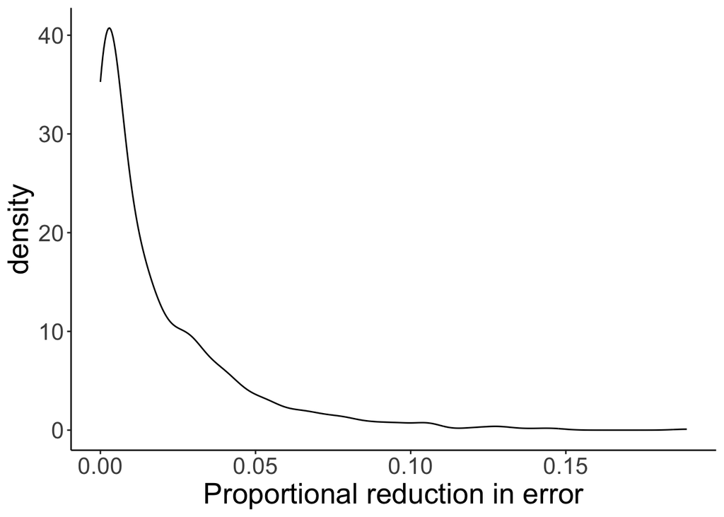

```r
# simulation parameters
n_samples = 1000
sample_size = 50
mu = 75 # true mean of the distribution
sigma = 5 # true standard deviation of the errors

# function to draw samples from the population distribution
fun.draw_sample = function(sample_size, mu, sigma){
  sample = mu + rnorm(sample_size,
                      mean = 0,
                      sd = sigma)
  return(sample)
}

# draw samples
samples = n_samples %>%
  replicate(fun.draw_sample(sample_size, mu, sigma)) %>%
  t() # transpose the resulting matrix (i.e. flip rows and columns)

# put samples in data frame and compute PRE
df.samples = samples %>%
  as_tibble(.name_repair = ~ str_c(1:ncol(samples))) %>%
  mutate(sample = 1:n()) %>%
  pivot_longer(cols = -sample,
               names_to = "index",
               values_to = "value") %>%
  mutate(compact = mu) %>%
  group_by(sample) %>%
  mutate(augmented = mean(value)) %>%
  summarize(sse_compact = sum((value - compact)^2),
            sse_augmented = sum((value - augmented)^2),
            pre = 1 - sse_augmented/sse_compact)


# plot the sampling distribution for PRE
ggplot(data = df.samples,
       mapping = aes(x = pre)) +
  stat_density(geom = "line") +
  labs(x = "Proportional reduction in error")

# calculate the p-value for our sample
df.samples %>%
  summarize(p_value = sum(pre >= df.summary$pre)/n())
```

Some code I wrote to show a subset of the samples.

```r
samples %>%
  as_tibble(.name_repair = "unique") %>%
  mutate(sample = 1:n()) %>%
  pivot_longer(cols = -sample,
               names_to = "index",
               values_to = "value") %>%
  mutate(compact = mu) %>%
  group_by(sample) %>%
  mutate(augmented = mean(value)) %>%
  ungroup() %>%
  mutate(index = str_extract(index, pattern = "\\-*\\d+\\.*\\d*"),
         index = as.numeric(index)) %>%
  filter(index < 6) %>%
  arrange(sample, index) %>%
    head(15) %>%
    kable(digits = 2) %>%
    kable_styling(bootstrap_options = "striped",
                full_width = F)
```

| sample | index | value | compact | augmented |
| --- | --- | --- | --- | --- |
| 1 | 1 | 76.99 | 75 | 75.59 |
| 1 | 2 | 71.94 | 75 | 75.59 |
| 1 | 3 | 76.71 | 75 | 75.59 |
| 1 | 4 | 69.35 | 75 | 75.59 |
| 1 | 5 | 82.17 | 75 | 75.59 |
| 2 | 1 | 71.90 | 75 | 74.24 |
| 2 | 2 | 75.21 | 75 | 74.24 |
| 2 | 3 | 70.45 | 75 | 74.24 |
| 2 | 4 | 75.79 | 75 | 74.24 |
| 2 | 5 | 71.73 | 75 | 74.24 |
| 3 | 1 | 77.25 | 75 | 75.38 |
| 3 | 2 | 74.91 | 75 | 75.38 |
| 3 | 3 | 73.41 | 75 | 75.38 |
| 3 | 4 | 70.35 | 75 | 75.38 |
| 3 | 5 | 67.56 | 75 | 75.38 |

## 9.5 Additional resources

### 9.5.1 Reading

- Judd, C. M., McClelland, G. H., & Ryan, C. S. (2011). Data analysis: A model comparison approach. Routledge. –> Chapters 1–4

### 9.5.2 Datacamp

- [Foundations of Inference](https://www.datacamp.com/courses/foundations-of-inference)